# gravicom

February 24, 2015

## Introduction

### Who cares and why did we make this?

## Networks

- Many relationships easily conceptualized as a graph/network
- A graph is defined as a collection of nodes (entities) and edges (relationships)
- A community is defined as a group of nodes in a graph that share properties
- Examples of such relationships include:
  - social networks (sociology)
  - the world wide web (computer science)
  - protein networks (biology)

## The Problem

- Current methodology for community detection often involves an algorithmic approach; partitions a graph into node clusters iteratively before stopping criterion
- First define an objective function and then optimize
- Many different objective functions possible, providing many ways to split a graph
- The optimization of an objective function is typically an NP-hard problem
- The number of possible partitions of the network requires \(2^n\) complexity

## Current Solutions

- Heuristics used to optimize the objective function in a reasonable amount of time
- Heuristic-based clustering is useful because this offers an automated way to perform community detection

> The main elements of the problem themselves [graph clustering], i.e. the concepts of community and partition, are not rigorously defined, and require some degree of arbitrariness and/or common sense. (Fortunato, 2010)
- Heuristics are not the solution

## Leverage the Human Visual System

- Communities are often fuzzily-defined human concepts
- Address this by adding element of human judgement
- Introduce a novel visualization-based community detection tool, gravicom

## gravicom Functionality

- Allows users to
  - Visually direct and interact with the steps of community detection
  - Assess the created clusters through visual and quantitative summaries
- Standalone exploratory tool for graph data
- Initial state to be passed to a community detection algorithm in order reduce the complexity of optimization

## Demo

### http://andeek.shinyapps.io/gravicom

- Shiny: Server-client interaction
- D3: User interface and graph layout
- igraph/rjson: Data formatting

## Football Example

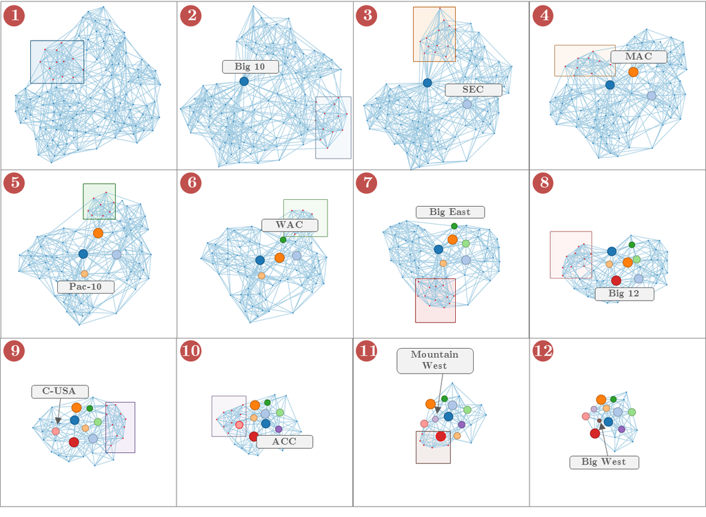

## Football Example (Cont'd)

| Conference | Teams Identified | Proportion | Accuracy |
| --- | --- | --- | --- |
| SEC | Vanderbilt, Florida, Louisiana State, South Carolina, Mississippi, Arkansas, Auburn, Kentucky, Georgia, Mississippi State, Alabama, Tennessee | 1.50 | 100% |
| MAC | *Central Florida*, Western Michigan, Miami Ohio, Ohio, Bowling Green State, Marshall, Ball State, Akron, Buffalo, Northern Illinois, Eastern Michigan, Toledo, Central Michigan, Kent | 1.46 | 92.9% |
| Big 12 | Kansas State, Iowa State, Kansas, Texas A& M, Texas Tech, Baylor, Missouri, Texas, Oklahoma State, Colorado, Oklahoma, Nebraska | 1.44 | 100% |
| ACC | Duke, Wake Forest, Virginia, Florida State, Clemson, North Carolina, Maryland, Georgia Tech, North Carolina State | 1.44 | 100% |
| Pac-10 | Arizona, Oregon State, Washington, Washington State, Arizona State, UC LA, Stanford, Southern California, Oregon, California | 1.33 | 100% |
| Big 10 | Ohio State, Penn State, Michigan, Michigan State, Purdue, Minnesota, Northwestern, Illinois, Iowa, Wisconsin, Indiana | 1.22 | 100% |
| WAC | Nevada, Fresno State, *Texas Christian*, Tulsa, Hawaii, Rice, Southern Methodist, San Jose State, Texas El Paso | 1.20 | 88.9% |
| Mountain West | Brigham Young, San Diego State, *Boise State*, Wyoming, New Mexico, Nevada Las Vegas, Utah, *North Texas*, *Utah State*, *New Mexico State*, Colorado State, *Arkansas State*, *Idaho*, Air Force | 0.96 | 57.1% |
| C-USA | Cincinnati, Louisville, Houston, Tulane, Southern Mississippi, Army, Memphis, East Carolina, Alabama Birmingham | 0.91 | 100% |
| Big East | Boston College, Miami Florida, Virginia Tech, Syracuse, Temple, West Virginia, *Connecticut*, Pittsburgh, Rutgers | 0.83 | 88.9% |
| Big West | Middle Tennessee State, Louisiana Lafayette, Louisiana Monroe, *Louisiana Tech* | 0.26 | 75% |
| Independent | Notre Dame, Notre Dame, Navy, Navy | 0.00 | 100% |

- Through manual specification of conferences, we were able to correctly classify 91.3% of the football teams into their conferences

## Graphical Devices

### Theory behind the curtain

## Importance of Graph Layout

- Graph layout is an assignment of a Cartesian coordinate to each node for display in 2D or 3D
- Layout of a graph significantly affects the number of communities that users detect within a graph
- Humans used to detect communities \(\Rightarrow\) special attention needs to be paid to the layout being used
- Location of a node spatially relative to other nodes in a cluster has a significant effect on user: "adjacent nodes must be placed near to each other if possible" (McGrath, Blythe, and Krackhardt, 1996)
- A force-directed layout satisfies these requirements by placing repulsive forces on nodes to separate all pairs of nodes with fixed-distance geometric constraints as links

## Graph Simplification

- Difficult to glean meaning from a visual representation in large/complex graphs
- Replace repeated patterns in a graph by a representation, to simplify a network
- Fewer nodes and edges to display \(\Rightarrow\) visual complexity of the graph visualization is greatly reduced
- Allows the user to analyze the network structure more accurately

## Conclusions/Further Work

### Possible extensions to gravicom

## Ideas

- Integrated algorithmic community detection
  - Combine the benefits of human detection of communities with algorithmic detection
  - Visual detection of communities serves as an initialization step, then pass to iterative algorithm
  - User tracks progress and has power to dynamically set stopping criterion
- Dynamic temporal graph visualization
  - View a dynamic graph across time – how the edges change between nodes
  - Detect time-dependent communities; Add optional node labels to track progress

## Questions?

### Thank you!

Contact:  
ajkaplan@iastate.edu

## Appendix

### Extra stuff and things.

## Page Lifecycle

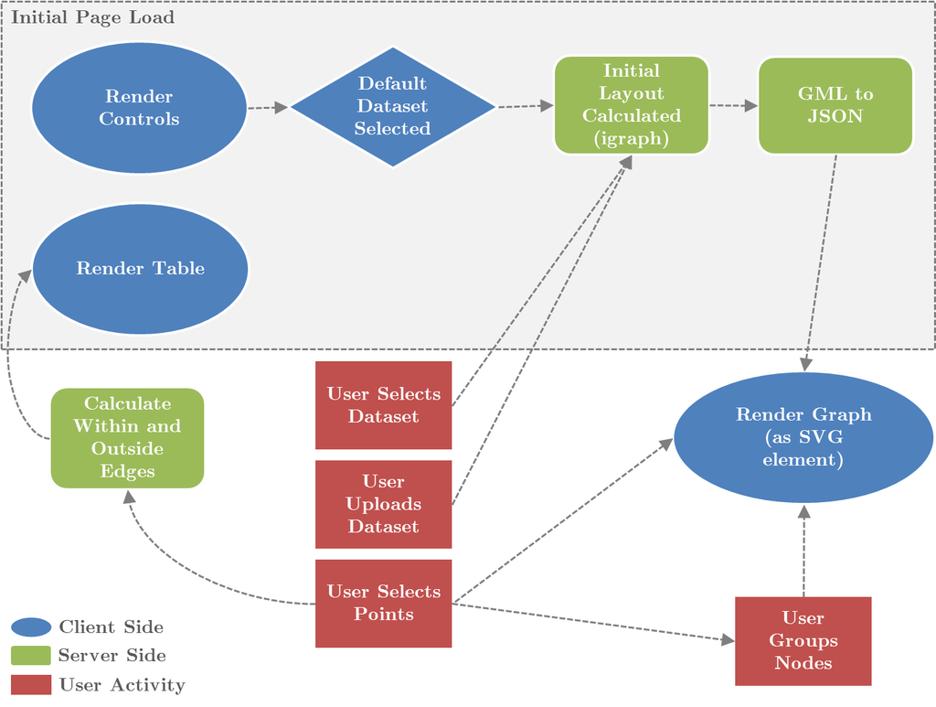

## Tools (Cont'd)

[figure not shown]

## Data Formatting

GML file structure:

```
## graph
## [
##   directed 0
##   node
##   [
##     id 0
##     label "Node 1"
##     value 100
##   ]
##   node
##   [
##     id 1
##     label "Node 2"
##     value 200
##   ]
##   edge
##   [
##     source 1
##     target 0
##   ]
## ]
```

JSON file structure:

```
## {
##   "nodes":
##   [{"id":"n0","v_id":"0","v_label":"Node 1","v_value":"100"},
##    {"id":"n1","v_id":"1","v_label":"Node 2","v_value":"200"}],
##  "edges":
##   [{"source":0, "target":1}]
## }
```

## References

Bostock, Michael, Vadim Ogievetsky, and Jeffrey Heer. 2011. “D3: Data-Driven Documents.” *IEEE Trans. Visualization & Comp. Graphics (Proc. InfoVis)*. http://vis.stanford.edu/files/2011-D3-InfoVis.pdf.

Couture-Beil, Alex. 2013. *Rjson: JSON for R*. http://CRAN.R-project.org/package=rjson.

Csardi, Gabor, and Tamas Nepusz. 2006. “The Igraph Software Package for Complex Network Research.” *InterJournal* Complex Systems: 1695. http://igraph.sf.net.

Fortunato, Santo. 2010. “Community Detection in Graphs.” *Physics Reports* 486 (3). Elsevier: 75–174.

Girvan, M., and M. E. J. Newman. 2002. “Community Structure in Social and Biological Networks.” *Proceedings of the National Academy of Sciences* 99 (12): 7821–26. doi:10.1073/pnas.122653799.

McGrath, Cathleen, Jim Blythe, and David Krackhardt. 1996. “Seeing Groups in Graph Layouts1.” *Connections* 19 (2): 22–29.

RStudio Inc. 2013. *Shiny: Web Application Framework for R*. http://CRAN.R-project.org/package=shiny.